# Risk Factor Analysis

## Outcome Variable

**Outcome Variable:** ever_sstunted

## Predictor Variables

**Intervention Variable:** mage

**Adjustment Set:**

- arm
- meducyrs
- feducyrs
- W_mhtcm
- single
- delta_meducyrs
- delta_feducyrs
- delta_W_mhtcm
- delta_single

## Stratifying Variables

The analysis was stratified on these variable(s):

- agecat
- studyid
- country

## Data Summary

| agecat | studyid | country | mage | ever_sstunted | n_cell | n |
| --- | --- | --- | --- | --- | --- | --- |
| 0-24 months | ki0047075b-MAL-ED | BANGLADESH | [20-30) | 0 | 148 | 265 |
| 0-24 months | ki0047075b-MAL-ED | BANGLADESH | [20-30) | 1 | 34 | 265 |
| 0-24 months | ki0047075b-MAL-ED | BANGLADESH | <20 | 0 | 29 | 265 |
| 0-24 months | ki0047075b-MAL-ED | BANGLADESH | <20 | 1 | 8 | 265 |
| 0-24 months | ki0047075b-MAL-ED | BANGLADESH | >=30 | 0 | 31 | 265 |
| 0-24 months | ki0047075b-MAL-ED | BANGLADESH | >=30 | 1 | 15 | 265 |
| 0-24 months | ki0047075b-MAL-ED | BRAZIL | [20-30) | 0 | 127 | 233 |
| 0-24 months | ki0047075b-MAL-ED | BRAZIL | [20-30) | 1 | 12 | 233 |
| 0-24 months | ki0047075b-MAL-ED | BRAZIL | <20 | 0 | 39 | 233 |
| 0-24 months | ki0047075b-MAL-ED | BRAZIL | <20 | 1 | 4 | 233 |
| 0-24 months | ki0047075b-MAL-ED | BRAZIL | >=30 | 0 | 49 | 233 |
| 0-24 months | ki0047075b-MAL-ED | BRAZIL | >=30 | 1 | 2 | 233 |
| 0-24 months | ki0047075b-MAL-ED | INDIA | [20-30) | 0 | 149 | 249 |
| 0-24 months | ki0047075b-MAL-ED | INDIA | [20-30) | 1 | 45 | 249 |
| 0-24 months | ki0047075b-MAL-ED | INDIA | <20 | 0 | 27 | 249 |
| 0-24 months | ki0047075b-MAL-ED | INDIA | <20 | 1 | 7 | 249 |
| 0-24 months | ki0047075b-MAL-ED | INDIA | >=30 | 0 | 19 | 249 |
| 0-24 months | ki0047075b-MAL-ED | INDIA | >=30 | 1 | 2 | 249 |
| 0-24 months | ki0047075b-MAL-ED | NEPAL | [20-30) | 0 | 173 | 240 |
| 0-24 months | ki0047075b-MAL-ED | NEPAL | [20-30) | 1 | 16 | 240 |
| 0-24 months | ki0047075b-MAL-ED | NEPAL | <20 | 0 | 3 | 240 |
| 0-24 months | ki0047075b-MAL-ED | NEPAL | <20 | 1 | 2 | 240 |
| 0-24 months | ki0047075b-MAL-ED | NEPAL | >=30 | 0 | 43 | 240 |
| 0-24 months | ki0047075b-MAL-ED | NEPAL | >=30 | 1 | 3 | 240 |
| 0-24 months | ki0047075b-MAL-ED | PERU | [20-30) | 0 | 121 | 303 |
| 0-24 months | ki0047075b-MAL-ED | PERU | [20-30) | 1 | 32 | 303 |
| 0-24 months | ki0047075b-MAL-ED | PERU | <20 | 0 | 62 | 303 |
| 0-24 months | ki0047075b-MAL-ED | PERU | <20 | 1 | 21 | 303 |
| 0-24 months | ki0047075b-MAL-ED | PERU | >=30 | 0 | 56 | 303 |
| 0-24 months | ki0047075b-MAL-ED | PERU | >=30 | 1 | 11 | 303 |

[output cut: 288 more lines]

The following strata were considered:

- agecat: 0-24 months, studyid: ki0047075b-MAL-ED, country: BANGLADESH
- agecat: 0-24 months, studyid: ki0047075b-MAL-ED, country: BRAZIL
- agecat: 0-24 months, studyid: ki0047075b-MAL-ED, country: INDIA
- agecat: 0-24 months, studyid: ki0047075b-MAL-ED, country: NEPAL
- agecat: 0-24 months, studyid: ki0047075b-MAL-ED, country: PERU
- agecat: 0-24 months, studyid: ki0047075b-MAL-ED, country: SOUTH AFRICA
- agecat: 0-24 months, studyid: ki0047075b-MAL-ED, country: TANZANIA, UNITED REPUBLIC OF
- agecat: 0-24 months, studyid: ki1000108-CMC-V-BCS-2002, country: INDIA
- agecat: 0-24 months, studyid: ki1000108-IRC, country: INDIA
- agecat: 0-24 months, studyid: ki1000109-EE, country: PAKISTAN
- agecat: 0-24 months, studyid: ki1000304b-SAS-CompFeed, country: INDIA
- agecat: 0-24 months, studyid: ki1000304b-SAS-FoodSuppl, country: INDIA
- agecat: 0-24 months, studyid: ki1017093-NIH-Birth, country: BANGLADESH
- agecat: 0-24 months, studyid: ki1017093b-PROVIDE, country: BANGLADESH
- agecat: 0-24 months, studyid: ki1017093c-NIH-Crypto, country: BANGLADESH
- agecat: 0-24 months, studyid: ki1066203-TanzaniaChild2, country: TANZANIA, UNITED REPUBLIC OF
- agecat: 0-24 months, studyid: ki1101329-Keneba, country: GAMBIA
- agecat: 0-24 months, studyid: ki1112895-Guatemala BSC, country: GUATEMALA
- agecat: 0-24 months, studyid: ki1112895-iLiNS-Zinc, country: BURKINA FASO
- agecat: 0-24 months, studyid: ki1113344-GMS-Nepal, country: NEPAL
- agecat: 0-24 months, studyid: ki1119695-PROBIT, country: BELARUS
- agecat: 0-24 months, studyid: ki1126311-ZVITAMBO, country: ZIMBABWE
- agecat: 0-24 months, studyid: ki1135781-COHORTS, country: GUATEMALA
- agecat: 0-24 months, studyid: ki1135781-COHORTS, country: INDIA
- agecat: 0-24 months, studyid: ki1135781-COHORTS, country: PHILIPPINES
- agecat: 0-24 months, studyid: ki1148112-LCNI-5, country: MALAWI
- agecat: 0-24 months, studyid: kiGH5241-JiVitA-3, country: BANGLADESH
- agecat: 0-6 months, studyid: ki0047075b-MAL-ED, country: BANGLADESH
- agecat: 0-6 months, studyid: ki0047075b-MAL-ED, country: BRAZIL
- agecat: 0-6 months, studyid: ki0047075b-MAL-ED, country: INDIA
- agecat: 0-6 months, studyid: ki0047075b-MAL-ED, country: NEPAL
- agecat: 0-6 months, studyid: ki0047075b-MAL-ED, country: PERU
- agecat: 0-6 months, studyid: ki0047075b-MAL-ED, country: SOUTH AFRICA
- agecat: 0-6 months, studyid: ki0047075b-MAL-ED, country: TANZANIA, UNITED REPUBLIC OF
- agecat: 0-6 months, studyid: ki1000108-CMC-V-BCS-2002, country: INDIA
- agecat: 0-6 months, studyid: ki1000108-IRC, country: INDIA
- agecat: 0-6 months, studyid: ki1000109-EE, country: PAKISTAN
- agecat: 0-6 months, studyid: ki1000304b-SAS-CompFeed, country: INDIA
- agecat: 0-6 months, studyid: ki1000304b-SAS-FoodSuppl, country: INDIA
- agecat: 0-6 months, studyid: ki1017093-NIH-Birth, country: BANGLADESH
- agecat: 0-6 months, studyid: ki1017093b-PROVIDE, country: BANGLADESH
- agecat: 0-6 months, studyid: ki1017093c-NIH-Crypto, country: BANGLADESH
- agecat: 0-6 months, studyid: ki1066203-TanzaniaChild2, country: TANZANIA, UNITED REPUBLIC OF
- agecat: 0-6 months, studyid: ki1101329-Keneba, country: GAMBIA
- agecat: 0-6 months, studyid: ki1112895-Guatemala BSC, country: GUATEMALA
- agecat: 0-6 months, studyid: ki1113344-GMS-Nepal, country: NEPAL
- agecat: 0-6 months, studyid: ki1119695-PROBIT, country: BELARUS
- agecat: 0-6 months, studyid: ki1126311-ZVITAMBO, country: ZIMBABWE
- agecat: 0-6 months, studyid: ki1135781-COHORTS, country: GUATEMALA
- agecat: 0-6 months, studyid: ki1135781-COHORTS, country: INDIA
- agecat: 0-6 months, studyid: ki1135781-COHORTS, country: PHILIPPINES
- agecat: 0-6 months, studyid: ki1148112-LCNI-5, country: MALAWI
- agecat: 0-6 months, studyid: kiGH5241-JiVitA-3, country: BANGLADESH

### Dropped Strata

Some strata were dropped due to rare outcomes:

- agecat: 0-24 months, studyid: ki0047075b-MAL-ED, country: BRAZIL
- agecat: 0-24 months, studyid: ki0047075b-MAL-ED, country: INDIA
- agecat: 0-24 months, studyid: ki0047075b-MAL-ED, country: NEPAL
- agecat: 0-24 months, studyid: ki1000109-EE, country: PAKISTAN
- agecat: 0-6 months, studyid: ki0047075b-MAL-ED, country: BANGLADESH
- agecat: 0-6 months, studyid: ki0047075b-MAL-ED, country: BRAZIL
- agecat: 0-6 months, studyid: ki0047075b-MAL-ED, country: INDIA
- agecat: 0-6 months, studyid: ki0047075b-MAL-ED, country: NEPAL
- agecat: 0-6 months, studyid: ki0047075b-MAL-ED, country: TANZANIA, UNITED REPUBLIC OF
- agecat: 0-6 months, studyid: ki1000108-IRC, country: INDIA
- agecat: 0-6 months, studyid: ki1000109-EE, country: PAKISTAN
- agecat: 0-6 months, studyid: ki1017093b-PROVIDE, country: BANGLADESH
- agecat: 0-6 months, studyid: ki1148112-LCNI-5, country: MALAWI

## Methods Detail

We’re interested in the causal parameters $E[Y_a]$ for all values of $a \in \mathcal{A}$. These parameters represent the mean outcome if, possibly contrary to fact, we intervened to set all units to have $A=a$. Under the randomization and positivity assumptions, these are identified by the statistical parameters $\psi_a=E_W[E_{Y|A,W}(Y|A=a,W)]$. In addition, we’re interested in the mean of $Y$, $E[Y]$ under no intervention (the observed mean). We will estimate these parameters by using SuperLearner to fit the relevant likelihood factors – $E_{Y|A,W}(Y|A=a,W)$ and $p(A=a|W)$, and then updating our likelihood fit using a joint TMLE.

For unadjusted analyses ($W=\{\}$), initial likelihoods were estimated using Lrnr_glm to estimate the simple $E(Y|A)$ and Lrnr_mean to estimate $p(A)$. For adjusted analyses, a small library containing Lrnr_glmnet, Lrnr_xgboost, and Lrnr_mean was used.

Having estimated these parameters, we will then use the delta method to estimate relative risks and attributable risks relative to a prespecified baseline level of $A$.

# Results Detail

## Results Plots

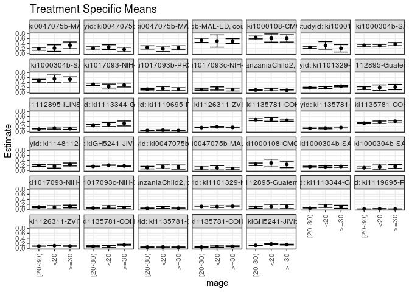

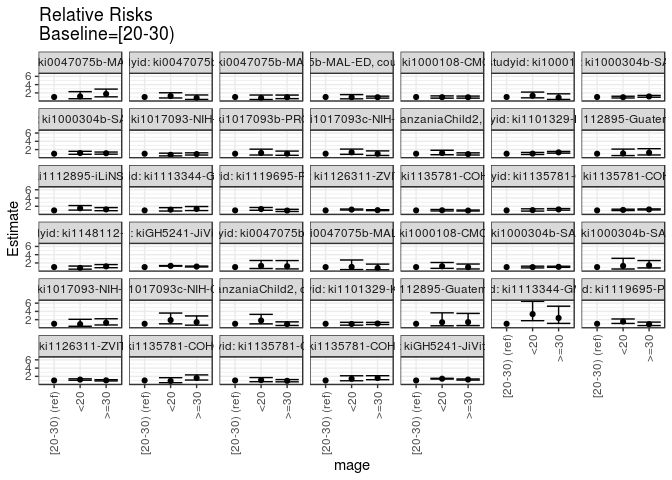

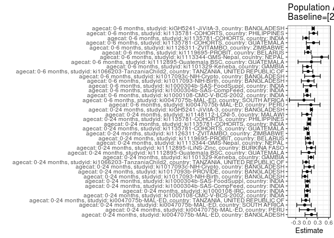

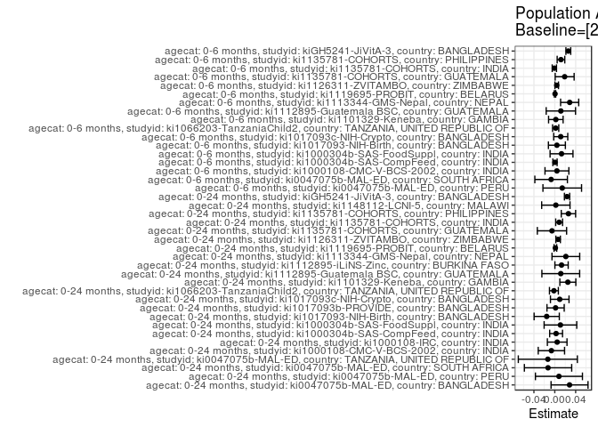

## Results Table

### Parameter: TSM

| agecat | studyid | country | intervention_level | baseline_level | estimate | ci_lower | ci_upper |
| --- | --- | --- | --- | --- | --- | --- | --- |
| 0-24 months | ki0047075b-MAL-ED | BANGLADESH | [20-30) | NA | 0.1868132 | 0.1300806 | 0.2435457 |
| 0-24 months | ki0047075b-MAL-ED | BANGLADESH | <20 | NA | 0.2162162 | 0.0833207 | 0.3491118 |
| 0-24 months | ki0047075b-MAL-ED | BANGLADESH | >=30 | NA | 0.3260870 | 0.1903623 | 0.4618116 |
| 0-24 months | ki0047075b-MAL-ED | PERU | [20-30) | NA | 0.2032598 | 0.1388363 | 0.2676833 |
| 0-24 months | ki0047075b-MAL-ED | PERU | <20 | NA | 0.2545597 | 0.1605797 | 0.3485397 |
| 0-24 months | ki0047075b-MAL-ED | PERU | >=30 | NA | 0.1603627 | 0.0705069 | 0.2502185 |
| 0-24 months | ki0047075b-MAL-ED | SOUTH AFRICA | [20-30) | NA | 0.2422360 | 0.1759512 | 0.3085209 |
| 0-24 months | ki0047075b-MAL-ED | SOUTH AFRICA | <20 | NA | 0.1875000 | 0.0769058 | 0.2980942 |
| 0-24 months | ki0047075b-MAL-ED | SOUTH AFRICA | >=30 | NA | 0.2285714 | 0.1481253 | 0.3090175 |
| 0-24 months | ki0047075b-MAL-ED | TANZANIA, UNITED REPUBLIC OF | [20-30) | NA | 0.5285714 | 0.4457249 | 0.6114179 |
| 0-24 months | ki0047075b-MAL-ED | TANZANIA, UNITED REPUBLIC OF | <20 | NA | 0.5000000 | 0.2545356 | 0.7454644 |
| 0-24 months | ki0047075b-MAL-ED | TANZANIA, UNITED REPUBLIC OF | >=30 | NA | 0.5000000 | 0.4046336 | 0.5953664 |
| 0-24 months | ki1000108-CMC-V-BCS-2002 | INDIA | [20-30) | NA | 0.6418919 | 0.5872000 | 0.6965838 |
| 0-24 months | ki1000108-CMC-V-BCS-2002 | INDIA | <20 | NA | 0.6176471 | 0.4540807 | 0.7812134 |
| 0-24 months | ki1000108-CMC-V-BCS-2002 | INDIA | >=30 | NA | 0.6046512 | 0.4583191 | 0.7509832 |
| 0-24 months | ki1000108-IRC | INDIA | [20-30) | NA | 0.2441860 | 0.1987326 | 0.2896395 |
| 0-24 months | ki1000108-IRC | INDIA | <20 | NA | 0.3243243 | 0.1733036 | 0.4753450 |
| 0-24 months | ki1000108-IRC | INDIA | >=30 | NA | 0.2068966 | 0.0592848 | 0.3545083 |
| 0-24 months | ki1000304b-SAS-CompFeed | INDIA | [20-30) | NA | 0.3281856 | 0.2910493 | 0.3653220 |
| 0-24 months | ki1000304b-SAS-CompFeed | INDIA | <20 | NA | 0.3135501 | 0.2634644 | 0.3636357 |
| 0-24 months | ki1000304b-SAS-CompFeed | INDIA | >=30 | NA | 0.3752350 | 0.3121314 | 0.4383385 |
| 0-24 months | ki1000304b-SAS-FoodSuppl | INDIA | [20-30) | NA | 0.4700344 | 0.4131437 | 0.5269251 |
| 0-24 months | ki1000304b-SAS-FoodSuppl | INDIA | <20 | NA | 0.5475875 | 0.3930913 | 0.7020837 |
| 0-24 months | ki1000304b-SAS-FoodSuppl | INDIA | >=30 | NA | 0.5243215 | 0.4219658 | 0.6266772 |
| 0-24 months | ki1017093-NIH-Birth | BANGLADESH | [20-30) | NA | 0.3280853 | 0.2835007 | 0.3726700 |
| 0-24 months | ki1017093-NIH-Birth | BANGLADESH | <20 | NA | 0.2386174 | 0.1377170 | 0.3395178 |
| 0-24 months | ki1017093-NIH-Birth | BANGLADESH | >=30 | NA | 0.2985832 | 0.2224936 | 0.3746727 |
| 0-24 months | ki1017093b-PROVIDE | BANGLADESH | [20-30) | NA | 0.1327510 | 0.1032216 | 0.1622804 |
| 0-24 months | ki1017093b-PROVIDE | BANGLADESH | <20 | NA | 0.1581322 | 0.0755243 | 0.2407402 |
| 0-24 months | ki1017093b-PROVIDE | BANGLADESH | >=30 | NA | 0.1329675 | 0.0741207 | 0.1918142 |

[output cut: 90 more lines]

### Parameter: E(Y)

| agecat | studyid | country | intervention_level | baseline_level | estimate | ci_lower | ci_upper |
| --- | --- | --- | --- | --- | --- | --- | --- |
| 0-24 months | ki0047075b-MAL-ED | BANGLADESH | NA | NA | 0.2150943 | 0.1655300 | 0.2646587 |
| 0-24 months | ki0047075b-MAL-ED | PERU | NA | NA | 0.2112211 | 0.1651858 | 0.2572564 |
| 0-24 months | ki0047075b-MAL-ED | SOUTH AFRICA | NA | NA | 0.2292994 | 0.1827279 | 0.2758709 |
| 0-24 months | ki0047075b-MAL-ED | TANZANIA, UNITED REPUBLIC OF | NA | NA | 0.5152672 | 0.4546361 | 0.5758983 |
| 0-24 months | ki1000108-CMC-V-BCS-2002 | INDIA | NA | NA | 0.6353887 | 0.5864772 | 0.6843003 |
| 0-24 months | ki1000108-IRC | INDIA | NA | NA | 0.2487805 | 0.2068840 | 0.2906770 |
| 0-24 months | ki1000304b-SAS-CompFeed | INDIA | NA | NA | 0.3307241 | 0.3024794 | 0.3589688 |
| 0-24 months | ki1000304b-SAS-FoodSuppl | INDIA | NA | NA | 0.4808612 | 0.4329065 | 0.5288160 |
| 0-24 months | ki1017093-NIH-Birth | BANGLADESH | NA | NA | 0.3125997 | 0.2762869 | 0.3489125 |
| 0-24 months | ki1017093b-PROVIDE | BANGLADESH | NA | NA | 0.1342857 | 0.1090095 | 0.1595619 |
| 0-24 months | ki1017093c-NIH-Crypto | BANGLADESH | NA | NA | 0.1306069 | 0.1066024 | 0.1546113 |
| 0-24 months | ki1066203-TanzaniaChild2 | TANZANIA, UNITED REPUBLIC OF | NA | NA | 0.0993266 | 0.0872975 | 0.1113557 |
| 0-24 months | ki1101329-Keneba | GAMBIA | NA | NA | 0.2151102 | 0.2000458 | 0.2301746 |
| 0-24 months | ki1112895-Guatemala BSC | GUATEMALA | NA | NA | 0.1886121 | 0.1427907 | 0.2344335 |
| 0-24 months | ki1112895-iLiNS-Zinc | BURKINA FASO | NA | NA | 0.1032421 | 0.0833685 | 0.1231156 |
| 0-24 months | ki1113344-GMS-Nepal | NEPAL | NA | NA | 0.2558140 | 0.2209310 | 0.2906969 |
| 0-24 months | ki1119695-PROBIT | BELARUS | NA | NA | 0.0394153 | 0.0310085 | 0.0478221 |
| 0-24 months | ki1126311-ZVITAMBO | ZIMBABWE | NA | NA | 0.1609064 | 0.1548268 | 0.1669861 |
| 0-24 months | ki1135781-COHORTS | GUATEMALA | NA | NA | 0.4639706 | 0.4374564 | 0.4904847 |
| 0-24 months | ki1135781-COHORTS | INDIA | NA | NA | 0.1370224 | 0.1277751 | 0.1462697 |
| 0-24 months | ki1135781-COHORTS | PHILIPPINES | NA | NA | 0.3561151 | 0.3391405 | 0.3730897 |
| 0-24 months | ki1148112-LCNI-5 | MALAWI | NA | NA | 0.2014925 | 0.1710974 | 0.2318877 |
| 0-24 months | kiGH5241-JiVitA-3 | BANGLADESH | NA | NA | 0.1836547 | 0.1780857 | 0.1892238 |
| 0-6 months | ki0047075b-MAL-ED | PERU | NA | NA | 0.1254125 | 0.0880603 | 0.1627648 |
| 0-6 months | ki0047075b-MAL-ED | SOUTH AFRICA | NA | NA | 0.0923567 | 0.0602816 | 0.1244318 |
| 0-6 months | ki1000108-CMC-V-BCS-2002 | INDIA | NA | NA | 0.2472826 | 0.2031431 | 0.2914222 |
| 0-6 months | ki1000304b-SAS-CompFeed | INDIA | NA | NA | 0.1496732 | 0.1307571 | 0.1685893 |
| 0-6 months | ki1000304b-SAS-FoodSuppl | INDIA | NA | NA | 0.1201923 | 0.0889059 | 0.1514788 |
| 0-6 months | ki1017093-NIH-Birth | BANGLADESH | NA | NA | 0.0940989 | 0.0712274 | 0.1169703 |
| 0-6 months | ki1017093c-NIH-Crypto | BANGLADESH | NA | NA | 0.0620053 | 0.0448256 | 0.0791849 |
| 0-6 months | ki1066203-TanzaniaChild2 | TANZANIA, UNITED REPUBLIC OF | NA | NA | 0.0433502 | 0.0351601 | 0.0515402 |
| 0-6 months | ki1101329-Keneba | GAMBIA | NA | NA | 0.1162505 | 0.1035378 | 0.1289632 |
| 0-6 months | ki1112895-Guatemala BSC | GUATEMALA | NA | NA | 0.0909091 | 0.0561653 | 0.1256529 |
| 0-6 months | ki1113344-GMS-Nepal | NEPAL | NA | NA | 0.0697674 | 0.0494002 | 0.0901347 |
| 0-6 months | ki1119695-PROBIT | BELARUS | NA | NA | 0.0142071 | 0.0107237 | 0.0176904 |
| 0-6 months | ki1126311-ZVITAMBO | ZIMBABWE | NA | NA | 0.0909999 | 0.0862375 | 0.0957624 |
| 0-6 months | ki1135781-COHORTS | GUATEMALA | NA | NA | 0.1008249 | 0.0829501 | 0.1186997 |
| 0-6 months | ki1135781-COHORTS | INDIA | NA | NA | 0.0482960 | 0.0424316 | 0.0541605 |
| 0-6 months | ki1135781-COHORTS | PHILIPPINES | NA | NA | 0.0624591 | 0.0538810 | 0.0710373 |
| 0-6 months | kiGH5241-JiVitA-3 | BANGLADESH | NA | NA | 0.1465812 | 0.1415687 | 0.1515938 |

### Parameter: RR

| agecat | studyid | country | intervention_level | baseline_level | estimate | ci_lower | ci_upper |
| --- | --- | --- | --- | --- | --- | --- | --- |
| 0-24 months | ki0047075b-MAL-ED | BANGLADESH | [20-30) | [20-30) | 1.0000000 | 1.0000000 | 1.000000 |
| 0-24 months | ki0047075b-MAL-ED | BANGLADESH | <20 | [20-30) | 1.1573927 | 0.5830963 | 2.297318 |
| 0-24 months | ki0047075b-MAL-ED | BANGLADESH | >=30 | [20-30) | 1.7455243 | 1.0427077 | 2.922061 |
| 0-24 months | ki0047075b-MAL-ED | PERU | [20-30) | [20-30) | 1.0000000 | 1.0000000 | 1.000000 |
| 0-24 months | ki0047075b-MAL-ED | PERU | <20 | [20-30) | 1.2523856 | 0.7718821 | 2.032007 |
| 0-24 months | ki0047075b-MAL-ED | PERU | >=30 | [20-30) | 0.7889544 | 0.4159728 | 1.496369 |
| 0-24 months | ki0047075b-MAL-ED | SOUTH AFRICA | [20-30) | [20-30) | 1.0000000 | 1.0000000 | 1.000000 |
| 0-24 months | ki0047075b-MAL-ED | SOUTH AFRICA | <20 | [20-30) | 0.7740385 | 0.4039953 | 1.483026 |
| 0-24 months | ki0047075b-MAL-ED | SOUTH AFRICA | >=30 | [20-30) | 0.9435897 | 0.6041851 | 1.473657 |
| 0-24 months | ki0047075b-MAL-ED | TANZANIA, UNITED REPUBLIC OF | [20-30) | [20-30) | 1.0000000 | 1.0000000 | 1.000000 |
| 0-24 months | ki0047075b-MAL-ED | TANZANIA, UNITED REPUBLIC OF | <20 | [20-30) | 0.9459459 | 0.5650100 | 1.583713 |
| 0-24 months | ki0047075b-MAL-ED | TANZANIA, UNITED REPUBLIC OF | >=30 | [20-30) | 0.9459459 | 0.7390120 | 1.210824 |
| 0-24 months | ki1000108-CMC-V-BCS-2002 | INDIA | [20-30) | [20-30) | 1.0000000 | 1.0000000 | 1.000000 |
| 0-24 months | ki1000108-CMC-V-BCS-2002 | INDIA | <20 | [20-30) | 0.9622291 | 0.7285538 | 1.270853 |
| 0-24 months | ki1000108-CMC-V-BCS-2002 | INDIA | >=30 | [20-30) | 0.9419829 | 0.7288118 | 1.217505 |
| 0-24 months | ki1000108-IRC | INDIA | [20-30) | [20-30) | 1.0000000 | 1.0000000 | 1.000000 |
| 0-24 months | ki1000108-IRC | INDIA | <20 | [20-30) | 1.3281853 | 0.8043984 | 2.193038 |
| 0-24 months | ki1000108-IRC | INDIA | >=30 | [20-30) | 0.8472906 | 0.4053311 | 1.771148 |
| 0-24 months | ki1000304b-SAS-CompFeed | INDIA | [20-30) | [20-30) | 1.0000000 | 1.0000000 | 1.000000 |
| 0-24 months | ki1000304b-SAS-CompFeed | INDIA | <20 | [20-30) | 0.9554046 | 0.7690293 | 1.186948 |
| 0-24 months | ki1000304b-SAS-CompFeed | INDIA | >=30 | [20-30) | 1.1433620 | 0.9488923 | 1.377687 |
| 0-24 months | ki1000304b-SAS-FoodSuppl | INDIA | [20-30) | [20-30) | 1.0000000 | 1.0000000 | 1.000000 |
| 0-24 months | ki1000304b-SAS-FoodSuppl | INDIA | <20 | [20-30) | 1.1649945 | 0.8590546 | 1.579891 |
| 0-24 months | ki1000304b-SAS-FoodSuppl | INDIA | >=30 | [20-30) | 1.1154961 | 0.8875581 | 1.401972 |
| 0-24 months | ki1017093-NIH-Birth | BANGLADESH | [20-30) | [20-30) | 1.0000000 | 1.0000000 | 1.000000 |
| 0-24 months | ki1017093-NIH-Birth | BANGLADESH | <20 | [20-30) | 0.7273029 | 0.4670682 | 1.132532 |
| 0-24 months | ki1017093-NIH-Birth | BANGLADESH | >=30 | [20-30) | 0.9100778 | 0.6839172 | 1.211026 |
| 0-24 months | ki1017093b-PROVIDE | BANGLADESH | [20-30) | [20-30) | 1.0000000 | 1.0000000 | 1.000000 |
| 0-24 months | ki1017093b-PROVIDE | BANGLADESH | <20 | [20-30) | 1.1911940 | 0.6747140 | 2.103029 |
| 0-24 months | ki1017093b-PROVIDE | BANGLADESH | >=30 | [20-30) | 1.0016305 | 0.6125871 | 1.637749 |

[output cut: 90 more lines]

### Parameter: PAR

| agecat | studyid | country | intervention_level | baseline_level | estimate | ci_lower | ci_upper |
| --- | --- | --- | --- | --- | --- | --- | --- |
| 0-24 months | ki0047075b-MAL-ED | BANGLADESH | [20-30) | NA | 0.0282812 | -0.0071337 | 0.0636960 |
| 0-24 months | ki0047075b-MAL-ED | PERU | [20-30) | NA | 0.0079613 | -0.0370997 | 0.0530223 |
| 0-24 months | ki0047075b-MAL-ED | SOUTH AFRICA | [20-30) | NA | -0.0129367 | -0.0582904 | 0.0324171 |
| 0-24 months | ki0047075b-MAL-ED | TANZANIA, UNITED REPUBLIC OF | [20-30) | NA | -0.0133043 | -0.0699133 | 0.0433048 |
| 0-24 months | ki1000108-CMC-V-BCS-2002 | INDIA | [20-30) | NA | -0.0065032 | -0.0317243 | 0.0187180 |
| 0-24 months | ki1000108-IRC | INDIA | [20-30) | NA | 0.0045944 | -0.0142326 | 0.0234215 |
| 0-24 months | ki1000304b-SAS-CompFeed | INDIA | [20-30) | NA | 0.0025384 | -0.0097874 | 0.0148643 |
| 0-24 months | ki1000304b-SAS-FoodSuppl | INDIA | [20-30) | NA | 0.0108268 | -0.0204477 | 0.0421014 |
| 0-24 months | ki1017093-NIH-Birth | BANGLADESH | [20-30) | NA | -0.0154857 | -0.0396492 | 0.0086779 |
| 0-24 months | ki1017093b-PROVIDE | BANGLADESH | [20-30) | NA | 0.0015347 | -0.0149819 | 0.0180513 |
| 0-24 months | ki1017093c-NIH-Crypto | BANGLADESH | [20-30) | NA | 0.0094845 | -0.0083157 | 0.0272848 |
| 0-24 months | ki1066203-TanzaniaChild2 | TANZANIA, UNITED REPUBLIC OF | [20-30) | NA | -0.0016726 | -0.0101817 | 0.0068365 |
| 0-24 months | ki1101329-Keneba | GAMBIA | [20-30) | NA | 0.0250299 | 0.0097090 | 0.0403508 |
| 0-24 months | ki1112895-Guatemala BSC | GUATEMALA | [20-30) | NA | 0.0114692 | -0.0247400 | 0.0476784 |
| 0-24 months | ki1112895-iLiNS-Zinc | BURKINA FASO | [20-30) | NA | 0.0129653 | 0.0002297 | 0.0257009 |
| 0-24 months | ki1113344-GMS-Nepal | NEPAL | [20-30) | NA | 0.0212138 | -0.0053442 | 0.0477717 |
| 0-24 months | ki1119695-PROBIT | BELARUS | [20-30) | NA | 0.0011229 | -0.0014628 | 0.0037086 |
| 0-24 months | ki1126311-ZVITAMBO | ZIMBABWE | [20-30) | NA | 0.0064185 | 0.0021063 | 0.0107306 |
| 0-24 months | ki1135781-COHORTS | GUATEMALA | [20-30) | NA | -0.0053945 | -0.0334511 | 0.0226621 |
| 0-24 months | ki1135781-COHORTS | INDIA | [20-30) | NA | 0.0083750 | 0.0017604 | 0.0149896 |
| 0-24 months | ki1135781-COHORTS | PHILIPPINES | [20-30) | NA | 0.0261723 | 0.0124201 | 0.0399245 |
| 0-24 months | ki1148112-LCNI-5 | MALAWI | [20-30) | NA | 0.0020296 | -0.0251347 | 0.0291939 |
| 0-24 months | kiGH5241-JiVitA-3 | BANGLADESH | [20-30) | NA | 0.0234867 | 0.0184466 | 0.0285267 |
| 0-6 months | ki0047075b-MAL-ED | PERU | [20-30) | NA | 0.0143014 | -0.0227196 | 0.0513225 |
| 0-6 months | ki0047075b-MAL-ED | SOUTH AFRICA | [20-30) | NA | -0.0070222 | -0.0382348 | 0.0241904 |
| 0-6 months | ki1000108-CMC-V-BCS-2002 | INDIA | [20-30) | NA | 0.0041319 | -0.0187459 | 0.0270097 |
| 0-6 months | ki1000304b-SAS-CompFeed | INDIA | [20-30) | NA | 0.0003931 | -0.0036599 | 0.0044461 |
| 0-6 months | ki1000304b-SAS-FoodSuppl | INDIA | [20-30) | NA | 0.0129259 | -0.0090278 | 0.0348795 |
| 0-6 months | ki1017093-NIH-Birth | BANGLADESH | [20-30) | NA | 0.0040515 | -0.0122133 | 0.0203163 |
| 0-6 months | ki1017093c-NIH-Crypto | BANGLADESH | [20-30) | NA | 0.0113980 | -0.0020788 | 0.0248748 |
| 0-6 months | ki1066203-TanzaniaChild2 | TANZANIA, UNITED REPUBLIC OF | [20-30) | NA | 0.0017104 | -0.0042159 | 0.0076367 |
| 0-6 months | ki1101329-Keneba | GAMBIA | [20-30) | NA | 0.0020377 | -0.0118944 | 0.0159697 |
| 0-6 months | ki1112895-Guatemala BSC | GUATEMALA | [20-30) | NA | 0.0116408 | -0.0164860 | 0.0397676 |
| 0-6 months | ki1113344-GMS-Nepal | NEPAL | [20-30) | NA | 0.0285303 | 0.0111666 | 0.0458940 |
| 0-6 months | ki1119695-PROBIT | BELARUS | [20-30) | NA | 0.0004920 | -0.0007620 | 0.0017459 |
| 0-6 months | ki1126311-ZVITAMBO | ZIMBABWE | [20-30) | NA | 0.0036988 | 0.0003011 | 0.0070965 |
| 0-6 months | ki1135781-COHORTS | GUATEMALA | [20-30) | NA | 0.0189198 | 0.0007755 | 0.0370642 |
| 0-6 months | ki1135781-COHORTS | INDIA | [20-30) | NA | -0.0008300 | -0.0049528 | 0.0032928 |
| 0-6 months | ki1135781-COHORTS | PHILIPPINES | [20-30) | NA | 0.0118420 | 0.0045519 | 0.0191321 |
| 0-6 months | kiGH5241-JiVitA-3 | BANGLADESH | [20-30) | NA | 0.0259425 | 0.0213281 | 0.0305568 |

### Parameter: PAF

| agecat | studyid | country | intervention_level | baseline_level | estimate | ci_lower | ci_upper |
| --- | --- | --- | --- | --- | --- | --- | --- |
| 0-24 months | ki0047075b-MAL-ED | BANGLADESH | [20-30) | NA | 0.1314826 | -0.0480346 | 0.2802503 |
| 0-24 months | ki0047075b-MAL-ED | PERU | [20-30) | NA | 0.0376918 | -0.2013389 | 0.2291625 |
| 0-24 months | ki0047075b-MAL-ED | SOUTH AFRICA | [20-30) | NA | -0.0564182 | -0.2737904 | 0.1238594 |
| 0-24 months | ki0047075b-MAL-ED | TANZANIA, UNITED REPUBLIC OF | [20-30) | NA | -0.0258201 | -0.1418377 | 0.0784094 |
| 0-24 months | ki1000108-CMC-V-BCS-2002 | INDIA | [20-30) | NA | -0.0102349 | -0.0507397 | 0.0287084 |
| 0-24 months | ki1000108-IRC | INDIA | [20-30) | NA | 0.0184679 | -0.0601792 | 0.0912807 |
| 0-24 months | ki1000304b-SAS-CompFeed | INDIA | [20-30) | NA | 0.0076754 | -0.0307262 | 0.0446463 |
| 0-24 months | ki1000304b-SAS-FoodSuppl | INDIA | [20-30) | NA | 0.0225155 | -0.0447441 | 0.0854451 |
| 0-24 months | ki1017093-NIH-Birth | BANGLADESH | [20-30) | NA | -0.0495383 | -0.1296841 | 0.0249215 |
| 0-24 months | ki1017093b-PROVIDE | BANGLADESH | [20-30) | NA | 0.0114287 | -0.1194517 | 0.1270072 |
| 0-24 months | ki1017093c-NIH-Crypto | BANGLADESH | [20-30) | NA | 0.0726188 | -0.0736976 | 0.1989962 |
| 0-24 months | ki1066203-TanzaniaChild2 | TANZANIA, UNITED REPUBLIC OF | [20-30) | NA | -0.0168390 | -0.1061793 | 0.0652857 |
| 0-24 months | ki1101329-Keneba | GAMBIA | [20-30) | NA | 0.1163585 | 0.0423613 | 0.1846378 |
| 0-24 months | ki1112895-Guatemala BSC | GUATEMALA | [20-30) | NA | 0.0608086 | -0.1518042 | 0.2341750 |
| 0-24 months | ki1112895-iLiNS-Zinc | BURKINA FASO | [20-30) | NA | 0.1255813 | -0.0051353 | 0.2392983 |
| 0-24 months | ki1113344-GMS-Nepal | NEPAL | [20-30) | NA | 0.0829266 | -0.0267967 | 0.1809250 |
| 0-24 months | ki1119695-PROBIT | BELARUS | [20-30) | NA | 0.0284890 | -0.0372177 | 0.0900332 |
| 0-24 months | ki1126311-ZVITAMBO | ZIMBABWE | [20-30) | NA | 0.0398895 | 0.0127364 | 0.0662957 |
| 0-24 months | ki1135781-COHORTS | GUATEMALA | [20-30) | NA | -0.0116269 | -0.0739320 | 0.0470635 |
| 0-24 months | ki1135781-COHORTS | INDIA | [20-30) | NA | 0.0611215 | 0.0117126 | 0.1080603 |
| 0-24 months | ki1135781-COHORTS | PHILIPPINES | [20-30) | NA | 0.0734939 | 0.0340163 | 0.1113581 |
| 0-24 months | ki1148112-LCNI-5 | MALAWI | [20-30) | NA | 0.0100728 | -0.1343598 | 0.1361156 |
| 0-24 months | kiGH5241-JiVitA-3 | BANGLADESH | [20-30) | NA | 0.1278850 | 0.1002235 | 0.1546961 |
| 0-6 months | ki0047075b-MAL-ED | PERU | [20-30) | NA | 0.1140351 | -0.2342485 | 0.3640391 |
| 0-6 months | ki0047075b-MAL-ED | SOUTH AFRICA | [20-30) | NA | -0.0760334 | -0.4719807 | 0.2134082 |
| 0-6 months | ki1000108-CMC-V-BCS-2002 | INDIA | [20-30) | NA | 0.0167093 | -0.0802810 | 0.1049916 |
| 0-6 months | ki1000304b-SAS-CompFeed | INDIA | [20-30) | NA | 0.0026265 | -0.0247542 | 0.0292757 |
| 0-6 months | ki1000304b-SAS-FoodSuppl | INDIA | [20-30) | NA | 0.1075433 | -0.0931481 | 0.2713896 |
| 0-6 months | ki1017093-NIH-Birth | BANGLADESH | [20-30) | NA | 0.0430557 | -0.1460825 | 0.2009803 |
| 0-6 months | ki1017093c-NIH-Crypto | BANGLADESH | [20-30) | NA | 0.1838229 | -0.0582042 | 0.3704948 |
| 0-6 months | ki1066203-TanzaniaChild2 | TANZANIA, UNITED REPUBLIC OF | [20-30) | NA | 0.0394559 | -0.1073319 | 0.1667854 |
| 0-6 months | ki1101329-Keneba | GAMBIA | [20-30) | NA | 0.0175283 | -0.1099492 | 0.1303650 |
| 0-6 months | ki1112895-Guatemala BSC | GUATEMALA | [20-30) | NA | 0.1280488 | -0.2387775 | 0.3862506 |
| 0-6 months | ki1113344-GMS-Nepal | NEPAL | [20-30) | NA | 0.4089347 | 0.1405820 | 0.5934945 |
| 0-6 months | ki1119695-PROBIT | BELARUS | [20-30) | NA | 0.0346276 | -0.0567021 | 0.1180637 |
| 0-6 months | ki1126311-ZVITAMBO | ZIMBABWE | [20-30) | NA | 0.0406458 | 0.0026203 | 0.0772216 |
| 0-6 months | ki1135781-COHORTS | GUATEMALA | [20-30) | NA | 0.1876503 | -0.0107411 | 0.3471009 |
| 0-6 months | ki1135781-COHORTS | INDIA | [20-30) | NA | -0.0171858 | -0.1062086 | 0.0646728 |
| 0-6 months | ki1135781-COHORTS | PHILIPPINES | [20-30) | NA | 0.1895964 | 0.0670385 | 0.2960546 |
| 0-6 months | kiGH5241-JiVitA-3 | BANGLADESH | [20-30) | NA | 0.1769836 | 0.1452383 | 0.2075499 |